# California Energy Conservation Assistance Act (ECAA): Loan Performance Analysis and Energy Savings Prediction for Public Sector Projects

**Study Details**

Author: Sarah Akhtar  
Affiliation: University of the Pacific  
Date: April 20th, 2025

**Overview**

The California Energy Conservation Assistance Act (ECAA), established under Public Resources Code §25410 et seq., serves as an essential funding resource for energy efficiency and renewable energy projects. Funding is provided through two major loan types: ECAA-Ed (zero-interest loans for K-12 schools) and ECAA-Reg (1% interest loans for cities, counties, tribes, and public institutions).

This study analyzes a California state-wide dataset of ECAA-funded projects reported by the State of California, where loans may amass to \$5 million dollars in supporting battery storage/EV infrastructure, annual savings projections of energy savings, and energy measures implementations (lighting, HVAC, solar). The major features examined included the project status (active/completed), DAC (disadvantaged community status), and utility partnerships; each is significant in measuring program effectiveness under AB33 (2021) which increased tribal eligibility and prioritized energy storage/EV infrastructure. The analysis employs machine learning for predictive modeling of energy savings and project completion outcomes while addressing equity considerations in loan distribution.

## Introduction: California Energy Conservation Assistance Act (ECAA) Overview

### Python Imports and Libraries

```python
import folium
import warnings
import pandas as pd
import numpy as np
import seaborn as sns
import matplotlib.pyplot as plt
from folium.plugins import MarkerCluster
from scipy import stats
from sklearn.neural_network import MLPRegressor, MLPClassifier
from sklearn.model_selection import train_test_split, GridSearchCV, learning_curve
from sklearn.preprocessing import StandardScaler
from sklearn.ensemble import RandomForestRegressor
from sklearn.metrics import mean_squared_error, r2_score, accuracy_score, confusion_matrix
from sklearn.metrics import classification_report, balanced_accuracy_score
from sklearn.tree import plot_tree
from sklearn.inspection import permutation_importance
from sklearn.feature_selection import SelectKBest, mutual_info_classif
from sklearn.decomposition import PCA
warnings.filterwarnings('ignore')
```

### Data Loading and Initial Exploration

The study introduction begins with loading the ECAA dataset from the "energy.csv" file into a `pandas` DataFrame named energy using `pd.read_csv()`. The `head()` method gives a first impression of the dataset structure, showing the first five rows for verifying successful loading and inspection of key variables such as `Approved_Loan_Amount`, `Project_Status`, and energy measure flags (`Lighting`, `HVAC`, `Solar`).

```python
energy = pd.read_csv('energy.csv')
energy.head()
```

|  | Address | City | County | Zip | Year | Recipient | Approved_Loan_Amount | Recipient_Type | Project_Type | Project_Status | ... | DDLon_D | GlobalID | CreationDate | Creator | EditDate | Editor | x | y | x2 | y2 |
| --- | --- | --- | --- | --- | --- | --- | --- | --- | --- | --- | --- | --- | --- | --- | --- | --- | --- | --- | --- | --- | --- |
| 0 | 26577 CA-18, Rimforest, CA 92378 | Rimforest | San Bernardino | 92378 | 2020.0 | Rim of the World Recreation and Parks | 156776 | Special District | ECAA-Reg | Completed | ... | -117.223759 | b24b3ec1-9c03-48e7-b288-f392bc5bd13a | 8/22/2022 3:59:00 PM | mlaw_CAEnergy | 7/19/2023 5:14:00 PM | SLocwood_CAEnergy | -117.223759 | 34.229645 | -13049289.16 | 4059679.579 |
| 1 | 3325 E Merced Falls Rd, Snelling, CA 95369 | Snelling | Merced | 95369 | 2020.0 | Snelling Community Services District | 220000 | Special District | ECAA-Reg | Completed | ... | -120.419066 | 8b380be0-f4c4-48be-8301-e7b1049daf76 | 8/22/2022 3:59:00 PM | mlaw_CAEnergy | 7/19/2023 5:14:00 PM | SLocwood_CAEnergy | -120.419066 | 37.521906 | -13404989.11 | 4512105.588 |
| 2 | 3101 Center St, Placerville, CA 95667 | Placerville | El Dorado | 95667 | 2019.0 | City of Placerville | 784112 | Local Government | ECAA-Reg | Completed | ... | -120.802628 | cfe61309-2d41-4459-8b52-ad4762a56c50 | 8/22/2022 3:59:00 PM | mlaw_CAEnergy | 7/19/2023 5:15:00 PM | SLocwood_CAEnergy | -120.802628 | 38.728678 | -13447687.04 | 4682881.207 |
| 3 | 250 N Ventura Rd, Port Hueneme, CA 93041 | Port Hueneme | Ventura | 93041 | 2019.0 | City of Port Hueneme | 840272 | Local Government | ECAA-Reg | Completed | ... | -119.194938 | 7b5d38cc-3edb-4867-88e5-7d1866945d41 | 8/22/2022 3:59:00 PM | mlaw_CAEnergy | 7/19/2023 5:15:00 PM | SLocwood_CAEnergy | -119.194938 | 34.149900 | -13268719.80 | 4048947.737 |
| 4 | 11330 Bullis Rd, Lynwood, CA 90262 | Lynwood | Los Angeles | 90262 | 2019.0 | City of Lynwood | 1700207 | Local Government | ECAA-Reg | Completed | ... | -118.199130 | 400c28c8-c7cb-4482-ba4b-7ac1ac85e498 | 8/22/2022 3:59:00 PM | mlaw_CAEnergy | 7/19/2023 5:15:00 PM | SLocwood_CAEnergy | -118.199130 | 33.926316 | -13157866.96 | 4018912.391 |

5 rows × 35 columns

### Source Links to Dataset and Information

Provided below are links to the dataset and information about the California ECAA dataset:

- **Dataset Link**: https://sandbox.data.ca.gov/dataset/energy-conservation-assistance-act-ecaa/f3b8112f-afaf-478a-9a6f-a2a4768907c8
- **Dataset Overview**: https://sandbox.data.ca.gov/dataset/energy-conservation-assistance-act-ecaa
- **Dataset Details**: https://data.ca.gov/dataset/energy-conservation-assistance-act-ecaa

### Descriptive Analysis: Dataset Variables

Each variable in the dataset represents the following information:

#### Project Information

- **Recipient**: Name of entity (school district, city, county, or public institution) approved for the ECAA loan.
- **Recipient_Type**: Type of recipient entity (e.g., school district, city, county, public institution).
- **Project_Type**: Whether loan is part of the ECAA-Ed (Education) program or the ECAA-Reg (Regular) program.
- **Project_Status**: Whether project is active (in-construction) or completed (achieving energy savings).
- **Approved_Loan_Amount**: Loan amount approved for the project at the time of approval.
- **Estimated_Savings**: Projected annual utility savings in dollars ($/yr) resulting from the project.
- **Annual_Electric_Savings**: Projected annual electric savings in kilowatt hours (kWh) resulting from the project.
- **Project_Summary**: Description of the project details.

#### Energy Measures (Yes/No)

- **Lighting**: Whether project involves lighting as an energy measure.
- **HVAC**: Whether project involves heating, ventilation, and air conditioning (HVAC) as an energy measure.
- **Solar**: Whether project involves solar energy as an energy measure.
- **Battery_Storage**: Whether project involves battery energy storage as an energy measure.
- **EV_Infrastructure**: Whether project involves electric vehicle (EV) charging infrastructure for public fleets.
- **Other**: Whether project involves other energy measures not listed above.

#### Utility Information

- **Utility**: Name of the utility company that supplies the loan recipient.
- **Type_Utility**: Whether the utility company is an Investor-Owned Utility (IOU) or a Publicly Owned Utility (POU).

#### Location Information

- **Address**: Physical address of the project location.
- **City**: City where the project is located.
- **County**: County where the project is located.
- **Zip**: ZIP code of the project location.
- **DAC**: Whether the loan recipient is located in a Disadvantaged Community (DAC) (Yes/No).
- **DDLat, DDLon**: Latitude and longitude coordinates of the project location (in original format).
- **DDLat_D, DDLon_D**: Latitude and longitude coordinates of the project location (in decimal degrees).
- **x, y**: Geographic coordinates of the location.
- **x2, y2**: Additional geographic coordinates of the location.

#### Temporal Information

- **Year**: Year when the project was approved or completed.
- **CreationDate**: Date when the record was created in the system.
- **EditDate**: Date when the record was last edited.
- **Creator**: User or system that created the record.
- **Editor**: User or system that last edited the record.

#### System Identifiers

- **GlobalID**: Unique identifier for the record in the system.

### Descriptive Analysis: Summary Statistics

This study will focus on key variables such as `Approved_Loan_Amount` (integer values representing loan sizes), `Annual_Electric_Savings` (projected energy savings in kWh), `Project_Type` (type of project), `DAC` (indicating if a project is located in a disadvantaged community), and the `Year` of approval.

```python
print("\n|---------Core Variables---------|")
print(energy[['Approved_Loan_Amount', 'Annual_Electric_Savings',
             'Project_Type', 'DAC', 'Year']].dtypes)
print("|--------------------------------|")
```

```
|---------Core Variables---------|
Approved_Loan_Amount         int64
Annual_Electric_Savings    float64
Project_Type                object
DAC                         object
Year                       float64
dtype: object
|--------------------------------|
```

The loan amounts vary widely, with a median of approximately \$185,000 but a maximum exceeding $29 million. This indicates a mix of small and large projects. Projected annual electric savings also show high variability, averaging around 472,000 kWh, though one anomalous negative value suggests a likely data entry issue.

```python
print("\n|-----------------Numerical Summary-----------------|")
print(energy[['Approved_Loan_Amount', 'Annual_Electric_Savings']].describe().apply(
    lambda x: round(x, 2) if x.dtype != 'object' else x))
print("|---------------------------------------------------|")
```

```
|-----------------Numerical Summary-----------------|
       Approved_Loan_Amount  Annual_Electric_Savings
count                943.00                   942.00
mean              638453.13                472566.62
std              1294025.61               1397721.71
min                 1678.00                 -2296.00
25%                48663.50                  3610.00
50%               184556.00                 98124.11
75%               788758.00                523850.00
max             29956662.00              34706857.00
|---------------------------------------------------|
```

Most projects (96.5%) are completed, with only a small fraction still active or canceled. Of the two types of ECAA Projects, the ECAA-Reg type encompasses 58.3% of the projects and 41.7% is the ECAA-Ed type. About 22% of projects are located in disadvantaged communities, highlighting some focus on equity but also suggesting room for increased investment in these areas.

```python
print("\n|-----Categorical Distributions-----|")
print("Project Status:")
print(energy['Project_Status'].value_counts(normalize=True).mul(100).round(1))
print("\nProject Type:")
print(energy['Project_Type'].value_counts(normalize=True).mul(100).round(1))
print("\nDisadvantaged Communities:")
print(energy['DAC'].value_counts(normalize=True).mul(100).round(1))
print("|-----------------------------------|")
```

```
|-----Categorical Distributions-----|
Project Status:
Project_Status
Completed    96.5
Active        3.4
Cancelled     0.1
Name: proportion, dtype: float64

Project Type:
Project_Type
ECAA-Reg    58.3
ECAA-Ed     41.7
Name: proportion, dtype: float64

Disadvantaged Communities:
DAC
No     77.6
Yes    22.4
Name: proportion, dtype: float64
|-----------------------------------|
```

### Data Cleaning: Filtering and Modifying Dataset

The dataset has been filtered and modified to maintain consistency through the following changes:

- Filled missing values in Yes/No columns (e.g., Lighting, HVAC, Solar) with "No", assuming missing indicates absence.
- Converted Yes/No responses to lowercase and mapped them to binary integers: 1 for "yes", 0 for "no".
- Removed unnecessary identifier columns such as OBJECTID and OID to streamline the dataset.
- Renamed variables containing spaces by replacing spaces with underscores (e.g., "Project Status" to Project_Status).

## Hypothesis Generation and Exploration: California Energy Conservation Assistance Act (ECAA) Dataset Analysis

### Questions: Funding Equity and Temporal Patterns in ECAA Projects

The following questions were developed to address pressing domains of the ECAA:

- Is there a significant difference in approved loan amounts between projects in Disadvantaged Communities (DACs) and non-DACs?
- How do project completion rates and timelines vary across fiscal years, and are there temporal trends in energy savings realization?

### Question #1: Approved Loan Amounts for Disadvantaged Communities

#### Data Cleaning and Preparation for Plotting

To create a visualization of the relationship between project types and identified disadvantaged communities, a subset is created (`dac_set`) by retaining rows with non-null values for `Approved_Loan_Amount`, `DAC`, and `Project_Type`. Next, it converts the `Approved_Loan_Amount` column to a numeric format, coercing any non-numeric entries to `NaN`. Finally, it removes rows with `NaN` values in `Approved_Loan_Amount` to ensure the dataset contains only valid loan amounts.

```python
dac_set = energy.dropna(subset=['Approved_Loan_Amount', 'DAC', 'Project_Type']).copy()
dac_set['Approved_Loan_Amount'] = pd.to_numeric(dac_set['Approved_Loan_Amount'], errors='coerce')
dac_set = dac_set.dropna(subset=['Approved_Loan_Amount'])
```

#### Approved Loan Amounts by DAC Status and Project Type

The snippet below creates a multi-panel visualization comparing approved loan amounts between disadvantaged communities (DACs) and non-DACs across project types. It maps a `catplot` with `boxen` plots for each `Project_Type` using a green-red palette to distinguish DAC (`Yes`) and non-DAC (`No`) categories. Loan amounts are plotted on a log scale to manage skewed distributions.

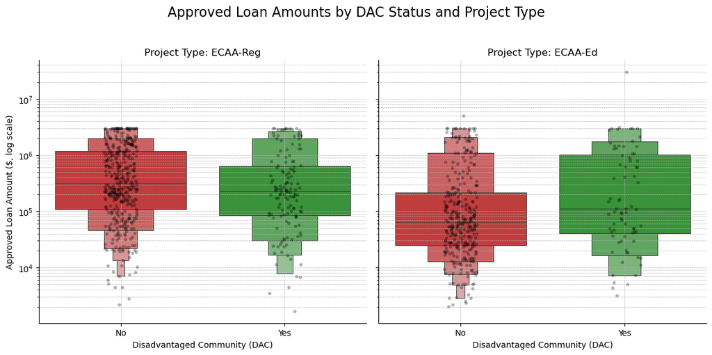

```python
plt.figure(figsize=(14,8))
graph = sns.catplot(dac_set, x='DAC', y='Approved_Loan_Amount', col='Project_Type', kind='boxen',
    palette={'Yes': '#2ca02c', 'No': '#d62728'}, showfliers=False, height=6, aspect=1
)

for ax, project_type in zip(graph.axes[0], dac_set['Project_Type'].unique()):
    subset = dac_set[dac_set['Project_Type'] == project_type]
    sns.stripplot(subset, x='DAC', y='Approved_Loan_Amount', ax=ax,
        jitter=True, color='black', alpha=0.3, size=4
    )
    ax.set_yscale('log')
    ax.set_ylabel('Approved Loan Amount ($, log scale)')
    ax.set_xlabel('Disadvantaged Community (DAC)')
    ax.set_title(f'Project Type: {project_type}')
    ax.grid(True, which="both", ls="--", linewidth=0.5)

plt.suptitle('Approved Loan Amounts by DAC Status and Project Type', fontsize=16)
plt.tight_layout(rect=[0, 0, 1, 0.95])
plt.show()
```

### Question #2: Geospatial Relationships and Timelines for Fiscal Years

#### Geospatial Distribution of DAC vs. Non-DAC Energy Loans Mapping

This visualization is created in conjunction with the *Approved Loan Amounts by DAC Status and Project Type* chart to visualize question one. The mapping begins by initializing an interactive map centered on California (latitude 36.7783, longitude -119.4179) with a default zoom level optimized for statewide perspective. Rows containing invalid geographic coordinates (NaN values in the `x` and `y` fields) are excluded from the dataset to ensure mapping accuracy. The filtered data is then converted to explicit floating-point coordinates.

```python
mapping_projects = folium.Map(location=[36.7783, -119.4179], zoom_start=6, control_scale=True)
valid_indices = []
for idx, row in energy.iterrows():
    if not (np.isnan(row['x']) or np.isnan(row['y'])):
        valid_indices.append(idx)
```

Two distinct marker clusters are implemented to differentiate projects within disadvantaged communities (DACs) from non-DAC initiatives. These clusters dynamically aggregate nearby projects at varying zoom levels, using color-coded grouping (green for DAC, red for non-DAC) to enable rapid visual distinction. The clustered approach prevents marker overlap in densely funded regions while preserving individual project visibility during zoom interactions.

```python
valid_energy = energy.loc[valid_indices].copy()
valid_energy['x'] = valid_energy['x'].astype(float)
valid_energy['y'] = valid_energy['y'].astype(float)
dac_cluster = MarkerCluster(name="DAC Projects").add_to(mapping_projects)
non_dac_cluster = MarkerCluster(name="Non-DAC Projects").add_to(mapping_projects)
```

Each valid project is represented as a proportional circle marker, where the radius corresponds to the approved loan amount (minimum 3 pixels, scaled by \$50,000 increments) to emphasize funding disparities. Color-coded markers (green/red) immediately convey DAC status, while interactive popups reveal detailed project specifics including city, county, loan amount, and physical address upon click. A silent error-handling mechanism ensures continuous execution during marker generation.

```python
for _, row in valid_energy.iterrows():
    try:
        marker = folium.CircleMarker(
            location=[row['y'], row['x']],
            radius=max(float(row['Approved_Loan_Amount'])/50000, 3),
            color='#2ca02c' if row['DAC'] == 'Yes' else '#d62728',
            fill=True,
            fill_opacity=0.7,
            popup=folium.Popup(f"""
                <b>{row['City']}</b><br>
                <b>County:</b> {row['County']}<br>
                <b>Loan:</b> ${row['Approved_Loan_Amount']:,}<br>
                <b>Address:</b> {row['Address']}
                """, max_width=300)
        )
        marker.add_to(dac_cluster if row['DAC'] == 'Yes' else non_dac_cluster)
    except Exception as e:
        print("")
folium.LayerControl(collapsed=False).add_to(mapping_projects)
```

```
<folium.map.LayerControl at 0x151c5a870>
```

The completed visualization incorporates a persistent layer control interface, allowing users to toggle DAC and non-DAC project layers independently. This interactive map enables stakeholders to identify geographic funding patterns, compare project distributions between community types, and investigate individual project details through its responsive design and multi-scale clustering behavior.

```python
mapping_projects
```

Make this Notebook Trusted to load map: File -> Trust Notebook

[interactive chart not shown]

#### Evaluating Geospatial Distribution of DAC vs. Non-DAC Energy Loans Mapping

The map displays the distribution of projects categorized as DAC (Disadvantaged Community) and non-DAC across California. Each location is marked with a colored circle containing a number, indicating the count of projects in that area. The Oakload area stands out with a high concentration, marked by a value of 323, highlighting it as a significant hub for both DAC and non-DAC projects. Other areas with high values include Los Angeles (114) and the region around Bakersfield and Stockton, indicating regional activity hotspots. Cities like Sacramento (56), Hanford (54), and San Diego (39) have moderate numbers of projects, suggesting a balanced distribution across these areas. The map illustrates that urban centers and certain regional hubs have higher project counts, likely due to greater population density and resource allocation, while more rural areas have fewer projects.

#### Project Completion Status vs Energy Savings Over Time [5]

This visualization tracks the median annual energy cost savings across different project types and completion statuses over time. A multi-variable line plot employs both color coding (for project status) and distinct marker styles (for project type) to simultaneously communicate two categorical dimensions. The chart calculates median savings values per year to mitigate outlier skewness, with connected markers emphasizing temporal trends. By combining status-based hue differentiation with project-type-specific line patterns, the plot enables cross-comparison of both operational completion progress and technology-specific savings trajectories.

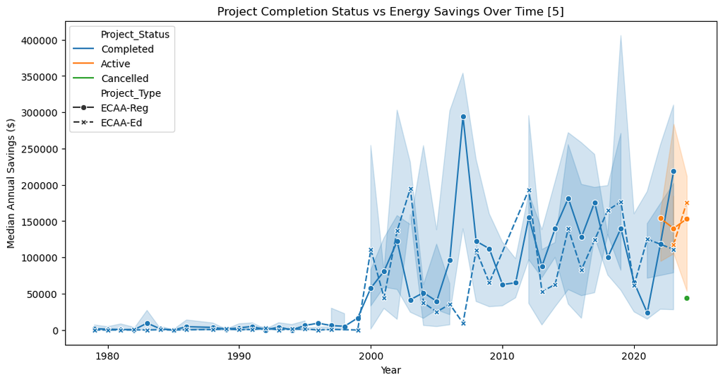

```python
plt.figure(figsize=(12,6))
timeline_plot = sns.lineplot(x='Year', y='Estimated_Savings',hue='Project_Status',
    style='Project_Type', data=energy, markers=True, estimator='median'
)
plt.title('Project Completion Status vs Energy Savings Over Time [5]')
plt.ylabel('Median Annual Savings ($)')
plt.show()
```

#### Evaluating Project Completion Status vs Energy Savings Over Time [5]

The chart shows the median annual energy savings over time from 1980 to 2023, colored by project completion status and type. Completed projects demonstrate significant fluctuations with peaks around the mid-2000s and near 2020. This indicates periods of high energy savings for ECAA projects. Active projects, represented in orange, show a recent increase, suggesting ongoing efforts with growing impact. The line for canceled projects, in green, is sparse, indicating fewer data points and less overall impact. Two project types, ECAA-Reg and ECAA-Ed, are marked with dots and crosses, respectively, showing variability in savings. The shaded areas represent uncertainty or variability in the data. Overall, there has been a trend toward higher energy savings in recent years, particularly for completed and active projects, highlighting advancements or increased focus on energy efficiency initiatives.

## Machine Learning: California Energy Conservation Assistance Act (ECAA) Predictive Modeling

This section explores two machine learning approaches, Random Forest regression and Neural Network classification, to model energy efficiency outcomes. The Random Forest predicts continuous *Estimated Savings* by analyzing project characteristics like loan amounts, technology adoption, and annual savings. The model is evaluated using feature importance and robust performance metrics such as R^2. Meanwhile, the Neural Network classifies *Project Types* using encoded categorical and scaled numerical features. Similarly, the model is evaluated using a confusion matrix, precision, recall, and F1 due to a slight imbalance in categorical variable (58/42) ratios. The Random Forest identifies key drivers of cost savings, while the Neural Network distinguishes between project categories with high accuracy. Visualizations like confusion matrices, loss curves, and permutation importance plots further refine the model behavior dynamics as well.

### Regression Machine Learning Model for Predicting Estimated Savings for ECAA Projects

#### Random Forest: Overview of Model

The following table depicts the independent and dependent variables used to train the model:

| Variable Name | Type | Description |
| --- | --- | --- |
| Approved_Loan_Amount | Feature | Amount of loan approved |
| Annual_Electric_Savings | Feature | Estimated annual electric savings |
| Year | Feature | Year of the record |
| Tech_Count | Feature | Number of technologies present |
| Loan_per_Saving | Feature | Loan amount divided by annual savings |
| Lighting | Feature | Binary: Lighting technology present |
| HVAC | Feature | Binary: HVAC technology present |
| Solar | Feature | Binary: Solar technology present |
| Battery_Storage | Feature | Binary: Battery storage present |
| EV_Infrastructure | Feature | Binary: EV infrastructure present |
| Other | Feature | Binary: Other technology present |
| Estimated_Savings | Target | The value being predicted |

#### Random Forest: Estimated Savings Prediction Model (Data Processing)

This snippet processes categorical "Yes/No" columns by converting them into binary numerical values (1 for "Yes," 0 for "No"). Missing values are filled with "No" to ensure consistency within the dataset. This is part of the data-cleaning process to ensure the model can train on these variables.

```python
yes_no_cols = ['Lighting', 'HVAC', 'Solar', 'Battery_Storage', 'EV_Infrastructure', 'Other']
for col in yes_no_cols:
    energy[col] = energy[col].fillna('No')
    energy[col] = energy[col].str.lower().map({'yes': 1, 'no': 0}).astype(int)
    energy[col] = energy[col].fillna(0).astype(int)
```

#### Random Forest: Estimated Savings Prediction Model (Feature Engineering and Selection)

A `Tech_Count` column is generated by summing all the binary technology adoption columns (e.g., Solar, Battery_Storage). Additionally, a `Loan_per_Saving` ratio is calculated by dividing the approved loan amount by the annual electric savings. The independent and dependent variables are also separated at this stage.

```python
energy['Tech_Count'] = energy[yes_no_cols].sum(axis=1)
energy['Loan_per_Saving'] = energy['Approved_Loan_Amount'] / (energy['Annual_Electric_Savings'] + 1)
features = ['Approved_Loan_Amount', 'Annual_Electric_Savings', 'Year', 'Tech_Count', 'Loan_per_Saving'] + yes_no_cols
X = energy[features].copy()
y = energy['Estimated_Savings'].fillna(0).astype(int)
```

#### Random Forest: Estimated Savings Prediction Model (Data Splitting and Tuning)

The data is split into training (80%) and testing (20%) sets to evaluate model performance. A hyperparameter grid is defined for tuning the Random Forest model. This includes options for the number of trees (`n_estimators`), tree depth (`max_depth`), split criteria (`min_samples_split`, `min_samples_leaf`), and feature selection strategy (`max_features`). This grid will be used in a cross-validated search to identify the best model configuration. The best model will then be used to predict the estimated savings of a project.

```python
X_train, X_test, y_train, y_test = train_test_split(X, y, test_size=0.2, random_state=42)
param_grid = {
    'n_estimators': [100, 200, 300],
    'max_depth': [None, 10, 20],
    'min_samples_split': [2, 5, 10],
    'min_samples_leaf': [1, 2, 4],
    'max_features': ['sqrt', 'log2']
}
```

#### Random Forest: Estimated Savings Prediction Model (Training Phase)

A `RandomForestRegressor` is initialized and optimized using `GridSearchCV`, which tests all combinations of hyperparameters from the predefined grid. The search employs 5-fold cross-validation and uses the R^2 score to evaluate performance.

```python
rf = RandomForestRegressor(random_state=42, n_jobs=-1)
grid_search = GridSearchCV(rf, param_grid, cv=5, scoring='r2', verbose=1)
grid_search.fit(X_train, y_train)
best_rf = grid_search.best_estimator_
print(f"Best Parameters: {grid_search.best_params_}")
```

```
Fitting 5 folds for each of 162 candidates, totalling 810 fits
Best Parameters: {'max_depth': None, 'max_features': 'sqrt', 'min_samples_leaf': 1, 'min_samples_split': 5, 'n_estimators': 300}
```

#### Random Forest: Estimated Savings Prediction Model (Performance Testing)

The trained Random Forest model predicts savings for both training and test sets. Performance metrics (R^2 and RMSE) are computed and displayed for each set.

```python
y_pred_train = best_rf.predict(X_train)
y_pred_test = best_rf.predict(X_test)

print("Random Forest Performance:")
print(f"Train R²: {r2_score(y_train, y_pred_train):.3f}")
print(f"Test R²: {r2_score(y_test, y_pred_test):.3f}")
print(f"Train RMSE: {np.sqrt(mean_squared_error(y_train, y_pred_train)):.2f}")
print(f"Test RMSE: {np.sqrt(mean_squared_error(y_test, y_pred_test)):.2f}")
```

```
Random Forest Performance:
Train R²: 0.973
Test R²: 0.911
Train RMSE: 14081.42
Test RMSE: 28633.80
```

#### Random Forest: Estimated Savings Prediction Model (Feature Importance Analysis)

The relative importance of each feature in the model's predictions is extracted and displayed in a sorted table. This helps identify which factors (e.g., loan amount, technology count) most influence energy savings estimates. The Annual Electric Savings, Approved Loan Amount, Year, and Loan per Saving are the features that contribute most to this model.

```python
importances = pd.DataFrame({
    'Feature': features,
    'Importance': best_rf.feature_importances_
}).sort_values('Importance', ascending=False)

print("Feature Importances:")
print(importances)
```

```
Feature Importances:
                    Feature  Importance
1   Annual_Electric_Savings    0.376557
0      Approved_Loan_Amount    0.318969
2                      Year    0.162993
4           Loan_per_Saving    0.053837
10                    Other    0.030588
7                     Solar    0.022453
5                  Lighting    0.020262
3                Tech_Count    0.010706
6                      HVAC    0.002992
9         EV_Infrastructure    0.000642
8           Battery_Storage    0.000000
```

#### Random Forest: Recommendations for Future Use

Based on the results and testing, this Random Forest model can be recommended for future predictions. The model demonstrates strong performance, with a training R^2 of 0.973 and a test R^2 of 0.911. This indicates that the model explains 97% of the variance in the training dataset and 91% of the variance in the test dataset. The high level of accuracy and performance on unseen data demonstrates that the model is effective at making reliable predictions. In addition to this, the model seems to generalize well with there being a moderate to low difference between the testing and training R^2 performances. However, there is a noticeable difference between the training and test RMSE values \$14,081 on the training set versus \$28,634 on the test set. This may indicate some overfitting, but the overall results make the model well for future use.

#### Visualizing Random Forest Model: Feature Importance

This chart ranks the predictive features by their importance in the Random Forest model. Longer bars indicate a stronger influence on the model's estimates of energy savings. For example, `Annual_Electric_Savings` has the longest bar, showing that the projected cost reductions play a key role in driving predictions.

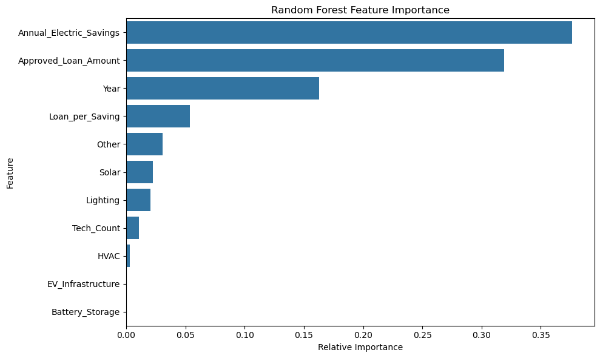

```python
plt.figure(figsize=(10, 6))
sns.barplot(x='Importance', y='Feature', data=importances.sort_values('Importance', ascending=False))
plt.title('Random Forest Feature Importance')
plt.xlabel('Relative Importance')
plt.tight_layout()
plt.show()
```

#### Visualizing Random Forest Model: Representative Decision Tree from Random Forest

The diagram visualizes one of the many decision trees in the Random Forest, limited to the first two levels for clarity. Each box (node) shows the splitting rule (e.g., `Lighting ≤ 0.5`), the number of samples, and the average savings prediction for that group. Darker shades often indicate higher certainty in predictions. This helps demystify how the model breaks down complex decisions into simpler, hierarchical rules.

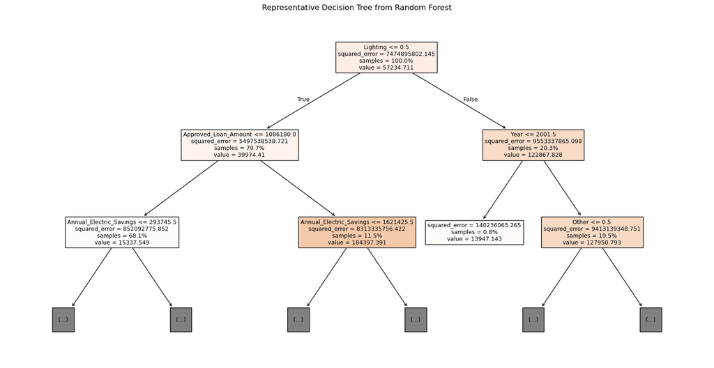

```python
single_tree = best_rf.estimators_[0]
plt.figure(figsize=(20, 10))
plot_tree(single_tree, feature_names=features, filled=True, max_depth=2, proportion=True)
plt.title("Representative Decision Tree from Random Forest")
plt.show()
```

#### Visualizing Random Forest Model: Actual vs. Predicted Savings

Each point represents a project, comparing its actual savings (x-axis) to the model’s predicted savings (y-axis). A perfect model would align all points along the red dashed line (y=x). Points above the line are overestimates; those below are underestimates.

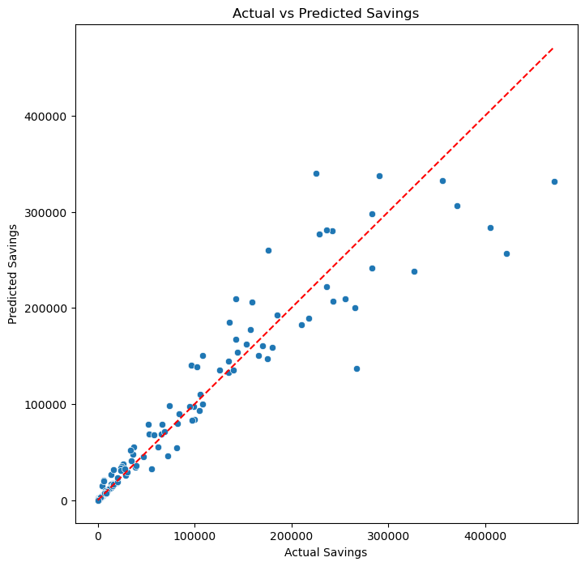

```python
plt.figure(figsize=(8, 8))
sns.scatterplot(x=y_test, y=y_pred_test)
plt.plot([y.min(), y.max()], [y.min(), y.max()], 'r--')
plt.xlabel('Actual Savings')
plt.ylabel('Predicted Savings')
plt.title('Actual vs Predicted Savings')
plt.show()
```

#### Visualizing Random Forest Model: Feature Correlation Matrix

The heatmap reveals how strongly each feature correlates with others and with the target (`Estimated_Savings`). Warm colors (red) show positive correlations (e.g., higher `Tech_Count` linking to greater savings), while cool colors (blue) indicate inverse relationships. Near-zero values (white) imply no linear association

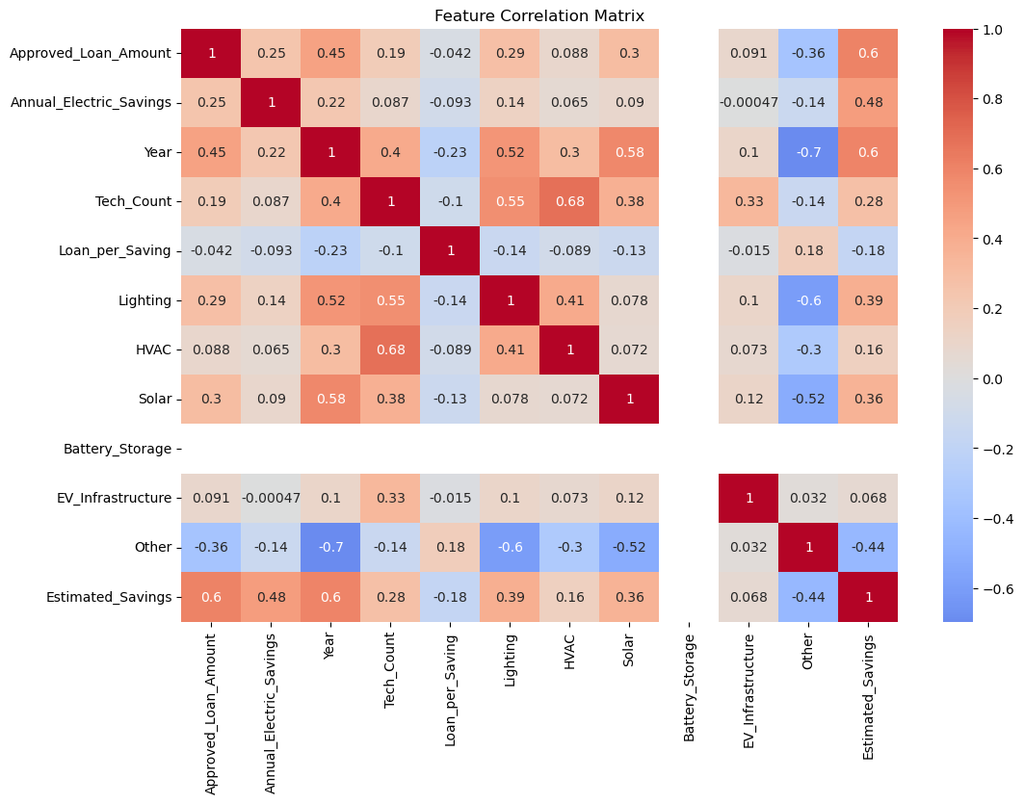

```python
plt.figure(figsize=(12, 8))
corr_matrix = X_train.join(y_train).corr()
sns.heatmap(corr_matrix, annot=True, cmap='coolwarm', center=0)
plt.title('Feature Correlation Matrix')
plt.show()
```

### Classification Machine Learning Model for Predicting ECAA Project Types

#### Neural Network: Overview of Model

The following table depicts the independent and dependent variables used to train the model:

| Variable Name | Type | Description |
| --- | --- | --- |
| Zip | Feature | Zip code of the project location |
| Year | Feature | Year of the project |
| Approved_Loan_Amount | Feature | Amount of loan approved for the project |
| Estimated_Savings | Feature | Estimated savings from the project |
| Annual_Electric_Savings | Feature | Estimated annual electric savings |
| DDLat_D | Feature | Latitude in decimal degrees |
| DDLon_D | Feature | Longitude in decimal degrees |
| x | Feature | X coordinate (engineered or projected coordinate) |
| y | Feature | Y coordinate (engineered or projected coordinate) |
| x2 | Feature | Additional X coordinate (engineered) |
| y2 | Feature | Additional Y coordinate (engineered) |
| Loan_per_Saving | Feature | Ratio of approved loan amount to annual electric savings |
| Address_1277 Blosser Ln, Willits, CA 95490 | Feature | Binary: Project at this specific address |
| Recipient_Type_Local Government | Feature | Binary: Recipient is a local government |
| Recipient_Type_School | Feature | Binary: Recipient is a school |
| Project_Summary_implement energy efficiency projects | Feature | Binary: Project summary mentions energy efficiency projects |
| Project_Summary_install energy efficient LED traffic lights | Feature | Binary: Project summary mentions installing LED traffic lights |
| DDLat_38.69091000N | Feature | Binary: Project at this specific latitude |
| DDLon_119.59856300W | Feature | Binary: Project at this specific longitude |
| DDLon_122.13533300W | Feature | Binary: Project at this specific longitude |
| Project_Type | Target | The type of project (classification target variable) |

**Note:** Additional features such as specific addresses, locations, recipient types, and latitude/longitude coordinates are independent features represented above. However, due to the variable results produced by neural network training, these features have been included in the table to serve only as examples that have been achieved in a past run.

#### Neural Network: Project Type Prediction Model (Data Preparation and Encoding)

This block creates a copy of the original dataset, selects all columns except `Project_Type` for encoding, and applies one-hot encoding to convert categorical variables into binary features. It then prepares the feature matrix `X_clf` and the target vector `y_clf` for classification, ensuring that any rows with missing values are removed.

```python
energy_clf = energy.copy()
features_to_encode = [col for col in energy_clf.columns if col not in ['Project_Type']]
energy_encoded = pd.get_dummies(energy_clf[features_to_encode], drop_first=True)
X_clf = energy_encoded.copy()
y_clf = energy_clf['Project_Type']
data_clf = pd.concat([X_clf, y_clf], axis=1).dropna()
X_clf = data_clf[energy_encoded.columns]
y_clf = data_clf['Project_Type']
```

#### Neural Network: Project Type Prediction Model (Train-Test Split)

Here, the data is split into training and testing sets using stratified sampling to preserve the distribution of the target classes. This ensures that both sets are representative of the overall class balance in the dataset. The test set encompasses 20% of the data.

```python
X_train_clf, X_test_clf, y_train_clf, y_test_clf = train_test_split(
    X_clf, y_clf, test_size=0.2, random_state=42, stratify=y_clf
)
```

#### Neural Network: Project Type Prediction Model (Feature Scaling)

This section standardizes the feature values using a `StandardScaler`, which transforms the data so that each feature has a mean of zero and a standard deviation of one. This step is important for neural networks to ensure stable and efficient training.

```python
scaler_clf = StandardScaler()
X_train_scaled = scaler_clf.fit_transform(X_train_clf)
X_test_scaled = scaler_clf.transform(X_test_clf)
```

#### Neural Network: Project Type Prediction Model (Feature Selection)

The `SelectKBest` method with mutual information is used to select the top 20 most relevant features for classification. This reduces dimensionality and helps the model focus on the most informative variables for the model.

```python
selector = SelectKBest(mutual_info_classif, k=20)
X_train_selected = selector.fit_transform(X_train_scaled, y_train_clf)
X_test_selected = selector.transform(X_test_scaled)
```

#### Neural Network: Project Type Prediction Model (Principal Component Analysis)

Here, Principal Component Analysis (PCA) is applied to further reduce dimensionality by transforming the selected features into principal components that explain 95% of the variance. This helps to eliminate redundancy and noise in the data.

```python
pca = PCA(n_components=0.95)
X_train_pca = pca.fit_transform(X_train_selected)
X_test_pca = pca.transform(X_test_selected)
```

#### Neural Network: Project Type Prediction Model (Classifier Initialization)

This portion initializes a multi-layer perceptron (MLP) classifier with two hidden layers and specified training parameters, setting up the neural network architecture for classification. The hidden layers have the dimensions of (100, 50) and use ReLU.

```python
nn_clf = MLPClassifier(hidden_layer_sizes=(100, 50), activation='relu', solver='adam',
    alpha=0.001, learning_rate='adaptive', early_stopping=True, validation_fraction=0.15,
    max_iter=2000, random_state=42
)
```

#### Neural Network: Project Type Prediction Model (Hyperparameter Grid Definition)

This block defines a grid of hyperparameters (such as hidden layer sizes, regularization strength, and learning rate) for tuning the neural network using grid search.

```python
param_grid = {
    'hidden_layer_sizes': [(50,), (100,50), (100,50,20)],
    'alpha': [0.0001, 0.001, 0.01],
    'learning_rate_init': [0.001, 0.01]
}
```

#### Neural Network: Project Type Prediction Model (Hyperparameter Optimization)

A grid search with cross-validation is performed to find the best combination of hyperparameters for the neural network, optimizing its performance based on the weighted F1 score.

```python
grid = GridSearchCV(nn_clf, param_grid, cv=5, scoring='f1_weighted', n_jobs=-1)
grid.fit(X_train_pca, y_train_clf)
```

```
GridSearchCV(cv=5,
             estimator=MLPClassifier(alpha=0.001, early_stopping=True,
                                     hidden_layer_sizes=(100, 50),
                                     learning_rate='adaptive', max_iter=2000,
                                     random_state=42,
                                     validation_fraction=0.15),
             n_jobs=-1,
             param_grid={'alpha': [0.0001, 0.001, 0.01],
                         'hidden_layer_sizes': [(50,), (100, 50),
                                                (100, 50, 20)],
                         'learning_rate_init': [0.001, 0.01]},
             scoring='f1_weighted')
```

#### Neural Network: Project Type Prediction Model (Model Selection and Prediction)

This section retrieves the best neural network model from the grid search and uses it to make predictions on the test set, preparing for evaluation.

```python
best_nn = grid.best_estimator_
y_pred_test = best_nn.predict(X_test_pca)
```

#### Neural Network: Project Type Prediction Model (Model Evaluation and Feature Reporting)

This block prints the class distribution, displays the confusion matrix and classification report, and shows the balanced accuracy score. It also lists the top features selected by the feature selection process.

```python
print("Class Distribution:")
print(y_clf.value_counts())
print("\nOptimized Model Performance:")
print(confusion_matrix(y_test_clf, y_pred_test))
print(classification_report(y_test_clf, y_pred_test))
print(f"Balanced Accuracy: {balanced_accuracy_score(y_test_clf, y_pred_test):.2f}")
selected_features = X_train_clf.columns[selector.get_support()]
print("\nTop Selected Features:")
print(selected_features)
```

```
Class Distribution:
Project_Type
ECAA-Reg    532
ECAA-Ed     382
Name: count, dtype: int64

Optimized Model Performance:
[[ 76   0]
 [  0 107]]
              precision    recall  f1-score   support

     ECAA-Ed       1.00      1.00      1.00        76
    ECAA-Reg       1.00      1.00      1.00       107

    accuracy                           1.00       183
   macro avg       1.00      1.00      1.00       183
weighted avg       1.00      1.00      1.00       183

Balanced Accuracy: 1.00

Top Selected Features:
Index(['Zip', 'Year', 'Approved_Loan_Amount', 'Estimated_Savings', 'DDLat_D',
       'DDLon_D', 'x', 'y', 'x2', 'y2', 'Loan_per_Saving',
       'Recipient_Campbell Unified School District -  Marshall Lane Elementary',
       'Recipient_City of Fowler', 'Recipient_City of Napa',
       'Recipient_McKinleyville Community Services District',
       'Recipient_Type_Local Government', 'Recipient_Type_School',
       'DDLon_122.23045600W', 'GlobalID_3e29724d-df05-4eb9-9503-f2b817956e53',
       'GlobalID_a2644d84-d191-4195-b4e1-c4cf9c8f47b1'],
      dtype='object')
```

#### Neural Network: Project Type Prediction Model (Training and Testing Accuracy)

The model’s accuracy on both the training and test datasets is calculated and displayed, providing a quick assessment of potential overfitting or underfitting.

```python
y_pred_train_clf = best_nn.predict(X_train_pca)
y_pred_test_clf = best_nn.predict(X_test_pca)
print("Classification Model Performance:")
print(f"Train Accuracy: {accuracy_score(y_train_clf, y_pred_train_clf):.3f}")
print(f"Test Accuracy: {accuracy_score(y_test_clf, y_pred_test_clf):.3f}")
```

```
Classification Model Performance:
Train Accuracy: 1.000
Test Accuracy: 1.000
```

#### Neural Network: Project Type Prediction Model (Selected Features Listing)

This lists the names of the selected features in the order they appear, which is useful for interpreting model inputs and understanding which variables are most influential.

```python
print("Selected Features in Order (as shown on x-axis):")
for i, feature in enumerate(selected_features):
    print(f"{i+1}. {feature}")
```

```
Selected Features in Order (as shown on x-axis):
1. Zip
2. Year
3. Approved_Loan_Amount
4. Estimated_Savings
5. DDLat_D
6. DDLon_D
7. x
8. y
9. x2
10. y2
11. Loan_per_Saving
12. Recipient_Campbell Unified School District -  Marshall Lane Elementary
13. Recipient_City of Fowler
14. Recipient_City of Napa
15. Recipient_McKinleyville Community Services District
16. Recipient_Type_Local Government
17. Recipient_Type_School
18. DDLon_122.23045600W
19. GlobalID_3e29724d-df05-4eb9-9503-f2b817956e53
20. GlobalID_a2644d84-d191-4195-b4e1-c4cf9c8f47b1
```

#### Neural Network: Project Type Prediction Model (Model Architecture)

This section prints details about the best neural network architecture, the number of input features after PCA, and the number of output classes, summarizing the model’s structure.

```python
print(f"Best model architecture: {best_nn.hidden_layer_sizes}")
print(f"Input features: {X_train_pca.shape[1]}")
print(f"Output classes: {len(best_nn.classes_)}")
```

```
Best model architecture: (100, 50, 20)
Input features: 13
Output classes: 2
```

#### Neural Network: Project Type Prediction Model (Confusion Matrix)

The confusion matrix provides a detailed breakdown of prediction quality, showing:

- True Positives/Negatives (correct classifications)
- False Positives/Negatives (misclassifications)

```python
cm = confusion_matrix(y_test_clf, y_pred_test_clf)
print("Confusion Matrix:")
print(cm)
```

```
Confusion Matrix:
[[ 76   0]
 [  0 107]]
```

#### Visualizing Neural Network Model: Learning Curve

This chart generates and plots a learning curve, showing the model’s performance (F1 score) on both training and validation sets as the number of training examples increases, helping to diagnose bias and variance issues. The training and validation scores follow closely, performing well when the training examples increase.

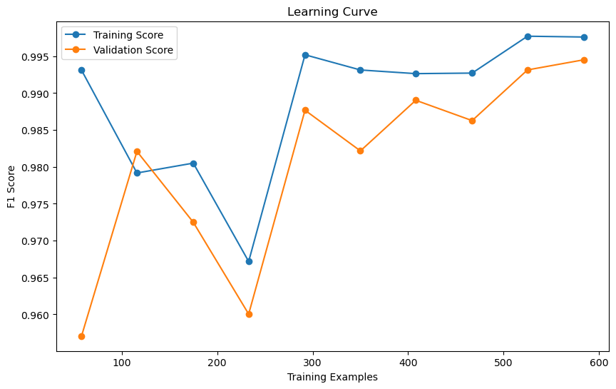

```python
train_sizes, train_scores, val_scores = learning_curve(
    best_nn, X_train_pca, y_train_clf,
    cv=5, scoring='f1_weighted', n_jobs=-1,
    train_sizes=np.linspace(0.1, 1.0, 10)
)

plt.figure(figsize=(10,6))
plt.plot(train_sizes, np.mean(train_scores, axis=1), 'o-', label='Training Score')
plt.plot(train_sizes, np.mean(val_scores, axis=1), 'o-', label='Validation Score')
plt.title('Learning Curve')
plt.xlabel('Training Examples')
plt.ylabel('F1 Score')
plt.legend()
plt.show()
```

#### Visualizing Neural Network Model: Loss Curve

In this section, the loss curve of the best neural network model is plotted over training epochs, providing insight into the model’s convergence behavior and training dynamics. As the epoch number increases, the loss curve slopes down to demonstrate the model is converging toward lower loss.

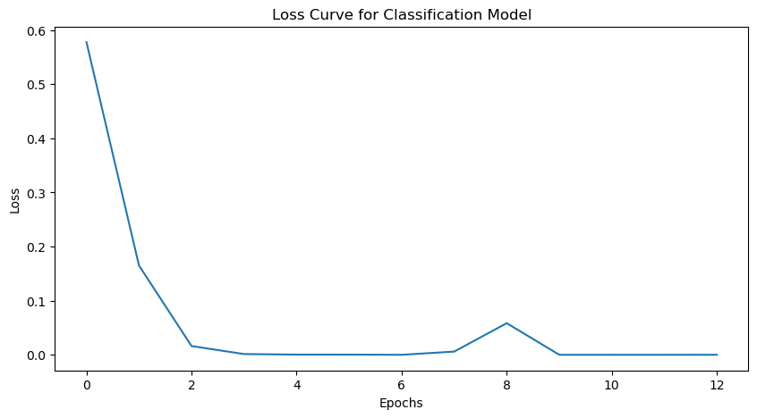

```python
best_params = grid.best_params_
best_nn_with_loss = MLPClassifier(**best_params, early_stopping=True, validation_fraction=0.15, max_iter=2000, random_state=42)
best_nn_with_loss.fit(X_train_pca, y_train_clf)
plt.figure(figsize=(10, 5))
plt.plot(best_nn_with_loss.loss_curve_)
plt.title("Loss Curve for Classification Model")
plt.xlabel("Epochs")
plt.ylabel("Loss")
plt.show()
```

#### Visualizing Neural Network Model: Confusion Matrix

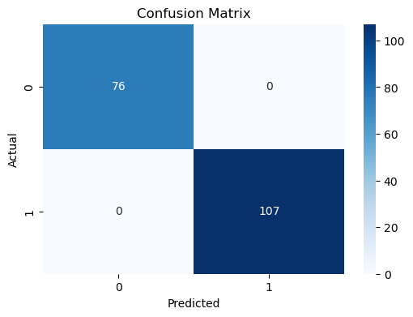

```python
plt.figure(figsize=(6, 4))
cm = confusion_matrix(y_test_clf, y_pred_test_clf)
sns.heatmap(cm, annot=True, fmt='d', cmap='Blues')
plt.xlabel('Predicted')
plt.ylabel('Actual')
plt.title('Confusion Matrix')
plt.show()
```

#### Visualizing Neural Network Model: Feature Importance (Test Set)

Finally, this block visualizes the loadings matrix from PCA, showing how the selected features contribute to the top principal components and how much variance each component explains, aiding in the interpretation of dimensionality reduction.

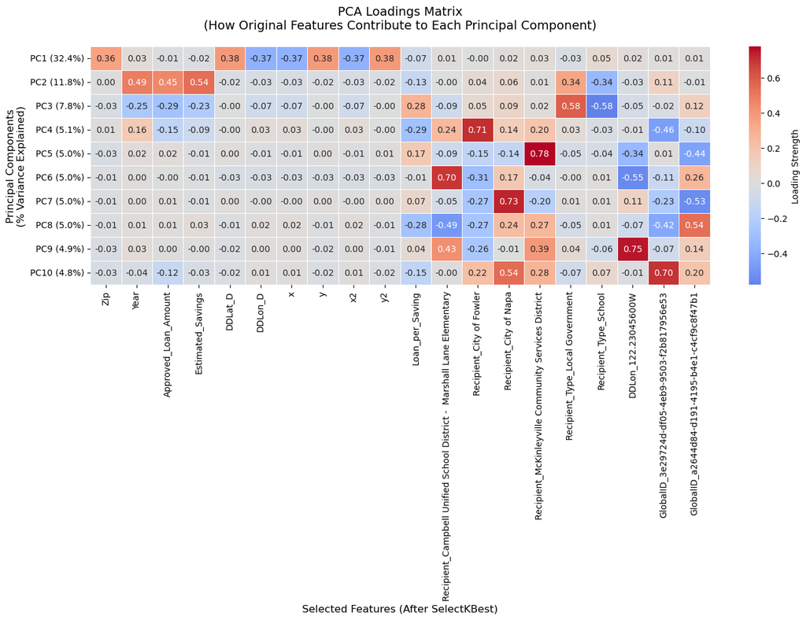

```python
loading_matrix = pca.components_
explained_variance = pca.explained_variance_ratio_
selected_features = X_train_clf.columns[selector.get_support()]
plt.figure(figsize=(14, 10))
top_n_pcs = 10
important_pcs = np.argsort(explained_variance)[::-1][:top_n_pcs]

heatmap = sns.heatmap(loading_matrix[important_pcs, :], xticklabels=selected_features,
    yticklabels=[f'PC{i+1} ({explained_variance[i]:.1%})' for i in important_pcs],
    cmap='coolwarm', center=0, annot=True, fmt=".2f", linewidths=0.5,
    cbar_kws={'label': 'Loading Strength'}
)

plt.xticks(rotation=90, ha='center', fontsize=10)
plt.yticks(rotation=0, fontsize=10)
plt.title("PCA Loadings Matrix\n(How Original Features Contribute to Each Principal Component)", pad=20, fontsize=14)
plt.xlabel("Selected Features (After SelectKBest)", fontsize=12)
plt.ylabel("Principal Components\n(% Variance Explained)", fontsize=12)
plt.tight_layout()
plt.show()
```

**Note**: Due to the nature of neural networks, the results vary between runs. If this model is trained on a new kernel and environment, the accuracy should remain 100% with a few differences in selected features. However, it is recommended to run this model a few times to view a better learning and loss curve with similar accuracy.

# Ethical Considerations: California Energy Conservation Assistance Act (ECAA) Review

### Introduction to Possible Ethical Concerns

The Energy Conservation Assistance Act (ECAA) dataset from the State of California involves a range of ethical considerations tied to core values of respect for persons, beneficence, justice, and compliance with public and legal standards. In regards to the respect for persons principle, although the data relates to addressing public ECAA projects as opposed to individual private data, the data includes precise geographic information and indicators relating to the condition of disadvantaged communities that may inadvertently result in the identification of vulnerable organizations or communities. In order to help maintain autonomy and protect confidentiality, there should be a system in the management of the data to aggregate or anonymize the geographic information to avoid inadvertent disclosures in areas that include tribal or rural programs.

### Respect for Persons

Regarding respect for persons, the data is mostly relevant to public endeavors as opposed to private ones; however, it does include detailed geographic information in the form of addresses and latitude/longitude coordinates, in addition to the designation of disadvantaged communities (DAC). This creates important implications regarding autonomy and privacy for vulnerable populations, such as tribal communities or small rural communities. Although the data is publicly available, it is important that sensitive location information be properly anonymized or aggregated to avoid the potential identification or exposure of the communities in question. In this sense, respecting individual rights requires a delicate balance between transparency of the identity and autonomy of the communities covered by the dataset.

### Beneficence

The ECAA dataset holds significant value in that it has the potential to perform analyses that optimize energy efficiency, promote fair loan distribution, and advance California's climate justice goals. Including factors such as Disadvantaged Community status and energy savings projections in the dataset allows for the deployment of targeted interventions designed to maximize positive outcomes for disadvantaged communities. There are, however, intrinsic risks involved in inflated savings projections or bias toward particular technologies or communities, which may result in inefficient allocation of resources or financial loss. To maintain a principle of beneficence, it is critical that the accuracy of such estimates is rigorously verified, modeling biases are minimized, and the benefits of the program are maximized without resulting in potential harm.

### Justice

Justice requires that no specific group should bear disproportionate costs while other groups receive serious benefits in the process. The current dataset acts as a vital tool in determining the fair distribution of loans and capital. There is a likelihood of wealthier or larger districts getting an unfair proportion of the finances in comparison to poor or tribal districts which might amplify entrenched system-based disparities. There is also the potential for data-driven machine-learning algorithms to amplify these disparities in case they are not designed with such factors of justice in mind. To achieve and adhere to justice, there is a need to perform frequent data and algorithmic audits to correct biases in order to promote fair access to conservation efforts for all communities.

### Respect for Law and Public Interest

Overall, the data complies with relevant legal frameworks and public policy (the respect for law and public interest principle), such as AB33 that expands tribal eligibility and prioritizes electric vehicle infrastructure initiatives. Distribution of loan and project-related information ensures transparency and accountability for the deployment of public funds. However, some gaps in demographic information as well as vague definitions of some implementation schemes for the deployment of energy projects may provide serious barriers to comprehensive public awareness and scrutiny. Compliance with legal standards and fulfilling public interests require constant efforts to improve data quality, secure compliance with privacy legislation, and provide clear explanations for the outcomes that relate to loan schemes in order to sustain public trust.

# Conclusion: Findings, Summary, and Next Steps

### Key Findings and Conclusions

This analysis of California's ECAA loan program reveals several important insights about funding distribution, energy savings outcomes, and predictive modeling performance. The data shows that while disadvantaged communities (DACs) receive comparable median loan amounts to non-DACs in ECAA-Reg projects, they benefit from higher and more variable funding in ECAA-Ed projects, suggesting targeted support for schools in underserved areas. Geographically, project distribution clusters in urban hubs like Oakland and Los Angeles, reflect population density and resource allocation patterns. Energy savings have generally increased over time, particularly for completed projects, indicating improved program effectiveness.

### Summary of Results and Performance Metrics

[output not shown]

### Final Assessment and Recommendations

The findings show that the ECAA program has succeeded in directing funds to disadvantaged communities, particularly in the education sector, while improving energy efficiency with concrete, measurable developments over the years. From the geographic concentration of activities, varying geographic areas are prominent features of the neural network model, demonstrating that there may be geographic bias in certain regions. The high performance of the regression predictive model underlines its use in providing estimated savings, suggesting that annual electric savings and temporal factors are what contribute to its effectiveness. Progressing forward, this study reveals that policymakers should consider the following changes: (1) expanding outreach to underserved rural communities, (2) utilizing predictive models to select projects with the highest impact while checking and auditing for potential biases, and (3) tracking energy savings to validate whether the program is meeting its goals. The combination of equity-focused design and data-driven decision-making positions the ECAA program to further enhance its impact on California's energy transition.